# Distribuzione campionaria della media

Didattica Integrativa - Analisi dei dati in psicologia dello sviluppo 2025-2026

Author

Matteo Manente

Published

26 May 2026

## A cosa serve la distribuzione campionaria della media?

Immaginiamo di voler sapere qual è il **livello medio di ansia** degli **studenti universitari** in Italia.

Idealmente, dovremmo misurare **tutti** gli studenti (l’intera **popolazione**). Nella pratica, però, questo è quasi sempre impossibile: richiederebbe troppo tempo, troppe risorse e spesso non è nemmeno fattibile.

Quello che facciamo davvero è prendere un **campione**, ad esempio 100 studenti, e calcolare la media dei loro livelli di ansia.

> **Ma quanto possiamo fidarci di questa media?**

Se prendessimo un altro campione di 100 studenti, probabilmente otterremmo una media leggermente diversa.  
E se ripetessimo questo processo molte volte, ogni campione produrrebbe una sua media.

Queste medie non sono tutte uguali, ma si **distribuiscono attorno al vero valore della popolazione**.

Ovviamente non possiamo davvero fare infiniti campioni. Ma possiamo **immaginare** questo processo per capire quanto varia la media.

La **distribuzione campionaria della media**, quindi, è alla base dell’**inferenza statistica**, cioè di quei metodi che ci permettono di passare da descrivere il nostro campione, a trarre conclusioni su una popolazione più ampia.

In altre parole:

> **Senza distribuzioni campionarie, non potremmo generalizzare i risultati delle nostre ricerche.**

Questo è particolarmente cruciale in **psicologia**, dove:

- raramente possiamo osservare l’intera popolazione
- lavoriamo quasi sempre con campioni limitati
- dobbiamo comunque prendere decisioni (cliniche, educative, organizzative)

La distribuzione campionaria ci dice **quanto possiamo fidarci** della media osservata nel nostro campione quando la usiamo per fare affermazioni sulla popolazione.

## Definizione

La **distribuzione campionaria della media** è proprio questo:

> **La distribuzione delle medie che otterremmo estraendo ripetutamente campioni della stessa numerosità dalla stessa popolazione.**

## Perché è fondamentale in psicologia?

La distribuzione campionaria della media ci permette di fare **inferenza**, cioè:

- stimare il **valore medio della popolazione**
- capire quanto è precisa la nostra **stima**
- quantificare l’**incertezza**

In altre parole, è lo strumento che ci consente di passare da:

- “Nel mio campione la media è 25”

a:

- “È plausibile che nella popolazione la media sia intorno a 25 (con un certo margine di errore)”

Quando lavoriamo con dati reali (test psicologici, interventi clinici, questionari), non stiamo mai osservando la popolazione completa.

Stiamo sempre lavorando con un campione.

> **La distribuzione campionaria della media è ciò che rende possibile trarre conclusioni affidabili dalla ricerca psicologica.**

Senza questo concetto, non potremmo prendere decisioni basate sui dati!

## Proprietà

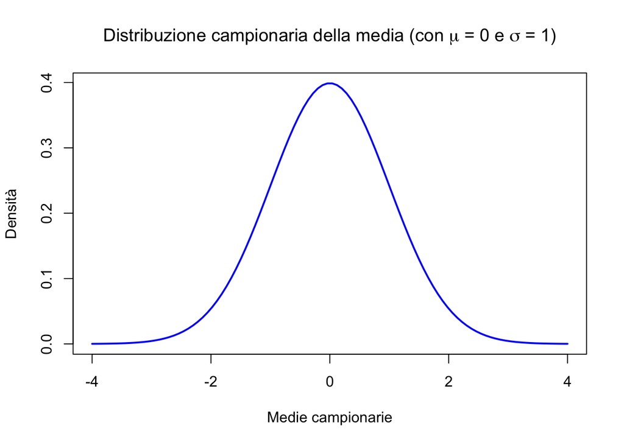

| Proprietà | Formula | Significato |
| --- | --- | --- |
| **Media** | $\mu_{\bar{x}} = \mu$ | La media della distribuzione campionaria delle medie è uguale alla media della popolazione |
| **Errore Standard** | $\sigma_{\bar{x}} = \frac{\sigma}{\sqrt{n}}$ | Indica quanto è preciso il valore medio che abbiamo calcolato: più è piccolo, più possiamo fidarci della nostra stima |

Secondo il **Teorema del Limite Centrale**, indipendentemente dalla forma della distribuzione nella popolazione (anche se è asimmetrica o non normale), la distribuzione delle medie campionarie tende ad assumere una forma **Normale** all’aumentare della numerosità campionaria (*n*).

> **In pratica: anche se i dati individuali non sono normali, le medie dei campioni lo diventano (quando *n* è sufficientemente grande).**

Le caratteristiche di questa distribuzione sono definite da due parametri fondamentali:

### 1. Media

La media di tutte le possibili medie campionarie è uguale alla media della popolazione:

$$\mu_{\bar{x}} = \mu$$

Questo significa che:

> **La media campionaria è uno *stimatore corretto* (non distorto) della media della popolazione.**

### 2. Varianza

La variabilità delle medie campionarie è **minore** della variabilità dei singoli individui.

La **varianza della distribuzione campionaria della media** è:

$$\sigma^2_{\bar{x}} = \frac{\sigma^2}{n}$$

e la sua deviazione standard, chiamata **Errore Standard della Media**, è:

$$\sigma_{\bar{x}} = \frac{\sigma}{\sqrt{n}}$$

L’**Errore Standard** ci dice:

> **Quanto, tipicamente, ci aspettiamo che la media campionaria vari da campione a campione per effetto del campionamento.**

L’Errore Standard, quindi, è ciò che ci permette di:

- costruire intervalli di fiducia
- fare test statistici
- prendere decisioni basate sui dati

**Nota**

Nella pratica, però, la deviazione standard della popolazione $\sigma$ è quasi sempre sconosciuta. Per questo, nei dati reali, l’Errore Standard viene stimato usando la deviazione standard campionaria:
$$SE = \frac{s}{\sqrt{n}}$$

dove $s$ è la deviazione standard del nostro campione e $n$ la numerosità campionaria.

#### Ad esempio

Supponiamo di utilizzare un test del QI (con deviazione standard $\sigma = 15$):

- Se consideriamo **un singolo individuo**, l’incertezza è elevata (15 punti)
- Se consideriamo un campione di **100 persone**:

$$\sigma_{\bar{x}} = \frac{15}{\sqrt{100}} = 1.5$$

👉 La variabilità delle medie è molto più piccola.

> **Più grande è il campione, più precisa è la nostra stima della media della popolazione.**

## Esempio

Supponiamo di voler stimare la media dei punteggi di QI di studenti/esse di psicologia dell’università di Padova (**Popolazione** = ca 7000 persone). Per semplicità, immaginiamo che i punteggi di QI nella popolazione seguano una distribuzione normale con media 100 e deviazione standard 15.

> **Il nostro obiettivo quindi è conoscere la media reale di questa popolazione**.

Possiamo però fare il test del QI solo a 50 studenti/esse (**Campione**).

```r
set.seed(1234)  # per uniformare i risultati

# Impostiamo i parametri veri della popolazione

mu <- 100     # media reale della popolazione

sigma <- 15   # deviazione standard reale nella popolazione



# Estraiamo il nostro campione di 50 studenti/esse dalla popolazione

n <- 50     # numerosità campionaria

campione <- rnorm(        # funzione per estrarre un campione da una distribuzione normale
  n = n,                  # con una certa numerosità campionaria (n, per noi: 50)
  mean = mu,              # media della popolazione (mu, per noi: 100)
  sd = sigma              # deviazione standard (sigma, per noi: 15)
)

campione
```

```
 [1]  81.89401 104.16144 116.26662  64.81453 106.43687 107.59084  91.37890
 [8]  91.80052  91.53322  86.64943  92.84211  85.02420  88.35619 100.96688
[15] 114.39241  98.34572  92.33486  86.33207  87.44242 136.23753 102.01132
[22]  92.63971  93.39178 106.89384  89.59420  78.27693 108.62134  84.64516
[29]  99.77293  85.96077 116.53446  92.86610  89.35840  92.48113  75.56360
[36]  82.48571  67.29941  79.88510  95.58559  93.01154 121.74244  83.97036
[43]  87.16953  95.79065  85.08490  85.47229  83.39023  81.22021  92.14258
[50]  92.54725
```

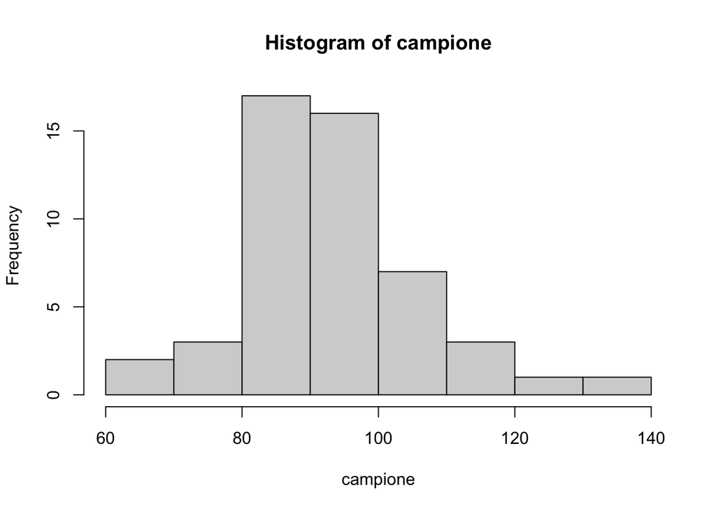

```r
# Visualizziamo la distribuzione di questo campione
hist(campione)
```

```r
# Calcoliamo la media del nostro campione
mean(campione)
```

```
[1] 93.2042
```

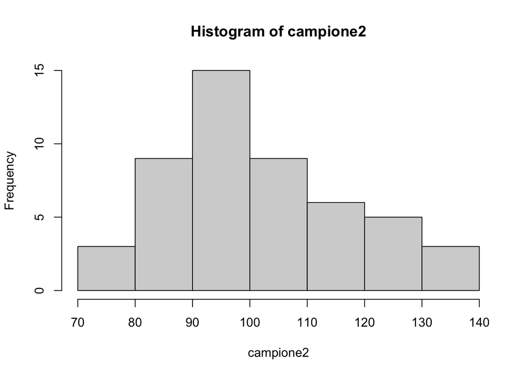

```r
## NB: La media del campione può essere diversa dalla media reale (qui: 93 vs 100).
## Questo è normale: è variabilità dovuta al campionamento.

# E se avessimo estratto un campione diverso?
campione2 <- rnorm(n = n, mean = mu, sd = sigma)

hist(campione2)
```

```r
mean(campione2)
```

```
[1] 102.0929
```

```r
## In questo caso la media è leggermente più alta rispetto alla media reale (102 vs 100).
```

Ora:

> **Simuliamo quello che non possiamo fare nella realtà: estrarre moltissimi campioni dalla stessa popolazione.**

Questo ci permette di “vedere” la distribuzione campionaria della media.

Operativamente:

- estraiamo 10’000 campioni con n = 50 dalla stessa popolazione
- calcoliamo la media di ogni campione (avremo quindi 10’000 medie)

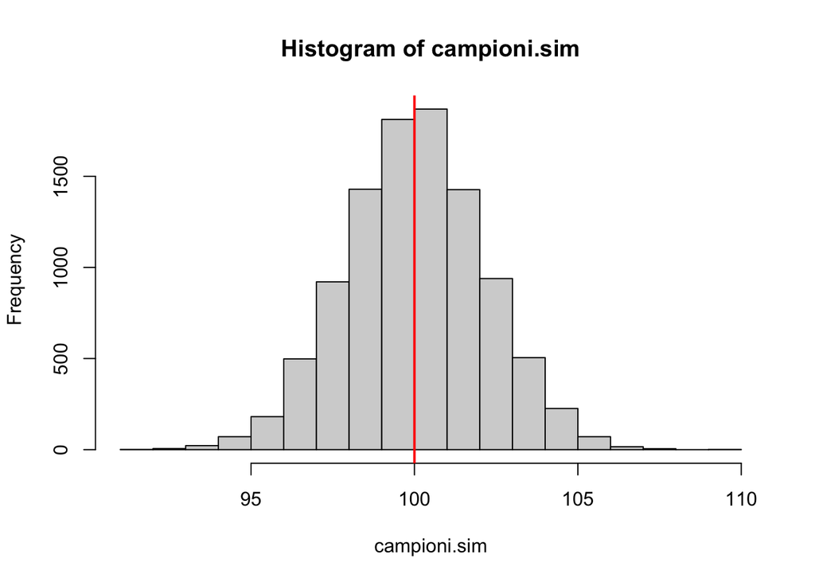

```r
B <- 10000       # numero di estrazioni (simulazioni)

campioni.sim <-
  replicate(           # funzione per replicare più volte una stessa operazione
  n = B,               # numero di "repliche" (10000)
  expr = mean(         # operazione da replicare: calcolare la media
    rnorm(             # di un campione estratto da una popolazione normale
      n = n,           # con numerosità campionaria = n (50)
      mean = mu,       # media = mu (100)
      sd = sigma))    # deviazione standard = sigma (15)
)

# Visualizziamo la distribuzione delle 10'000 medie simulate
hist(campioni.sim)
abline(v = mu, lwd = 2, col = "red")
```

```r
# Calcoliamo la media della distribuzione campionaria
media.distr.camp <- round(mean(campioni.sim), 2)
media.distr.camp
```

```
[1] 100.02
```

```r
## NB: molto vicina alla media reale (100.02 ~ 100)


# Calcoliamo la deviazione standard della distribuzione campionaria
## Cioè quanto varia la media campionaria tra campioni diversi (Errore Standard)
se.distr.camp <- round(sd(campioni.sim), 2)
se.distr.camp
```

```
[1] 2.13
```

```r
# Verifichiamo ora con il calcolo analitico di media e dev. standard della distribuzione campionaria della media (Vedi "Proprietà")

## Media analitica (= 100, cioè la media reale della nostra popolazione)

media <- round(mu, 2)
media
```

```
[1] 100
```

```r
## Standard Error analitico
se <- round(sigma/sqrt(n), 2)
se
```

```
[1] 2.12
```

```r
# Confrontiamoli
mat <- matrix(data = c(media, media.distr.camp, se, se.distr.camp),
              nrow = 2, ncol = 2,
              byrow = TRUE)

rownames(mat) <- c("Media", "Errore Standard")
colnames(mat) <- c("Analitico", "Simulato")

mat
```

```
                Analitico Simulato
Media              100.00   100.02
Errore Standard      2.12     2.13
```

## Riassumendo

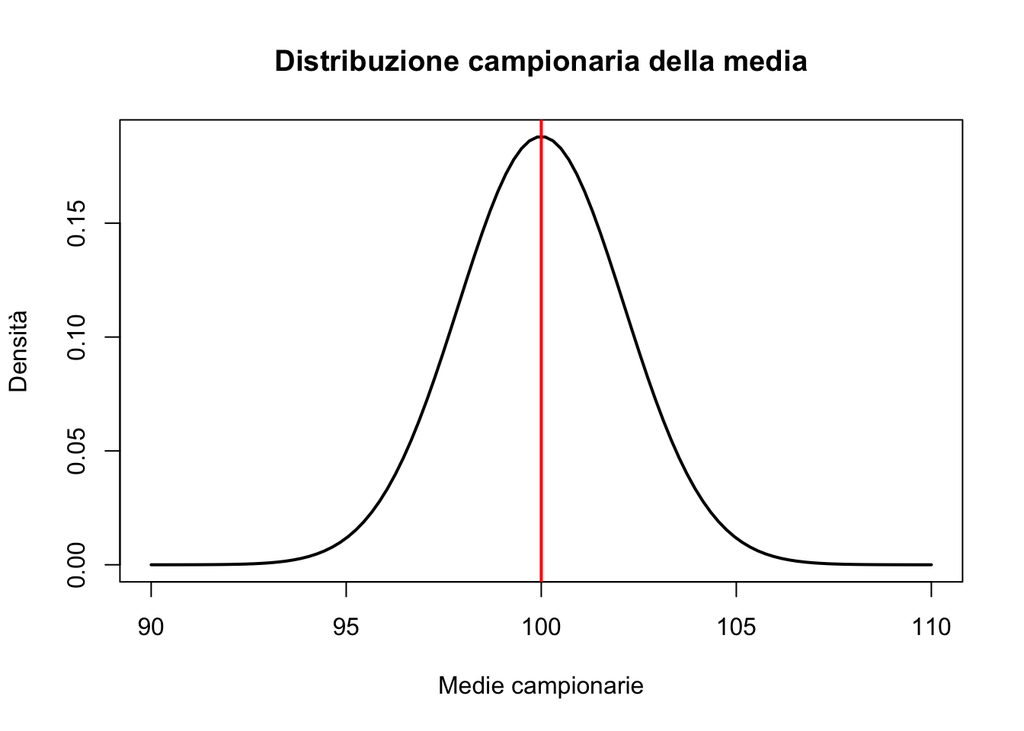

```r
mu <- 100       # media della popolazione
sigma <- 15     # deviazione standard nella popolazione
n <- 50         # campione

se <- sigma / sqrt(n)     # calcolo dello standard error della media campionaria

x <- seq(from = 90, to = 110, length.out = 100)
y <- dnorm(x, mean = mu, sd = se)

plot(
  x, y,
  type = "l",
  lwd = 2,
  xlab = "Medie campionarie",
  ylab = "Densità",
  main = "Distribuzione campionaria della media"
)

abline(v = mu, lwd = 2, col = "red")
```

| Proprietà | Formula | Significato |
| --- | --- | --- |
| **Media** | $\mu_{\bar{x}} = \mu$ | La media della distribuzione campionaria delle medie è uguale alla media della popolazione |
| **Errore Standard** | $\sigma_{\bar{x}} = \frac{\sigma}{\sqrt{n}}$ | Indica quanto è preciso il valore medio che abbiamo calcolato: più è piccolo, più possiamo fidarci della nostra stima |

- Le medie dei campioni estratti da una stessa popolazione **variano**
- Questa variabilità è descritta dalla **distribuzione campionaria della media**
- La media di questa distribuzione è uguale alla **media reale della popolazione**
- La sua deviazione standard è l’**Errore Standard** e indica la **precisione della stima della media**. Diminuisce all’aumentare di *n*: più grande è il campione, meno le medie campionarie variano tra loro (cioè la stima è più stabile e precisa).

> **Questo è il motivo per cui possiamo fare inferenza:**  
> anche se osserviamo un solo campione, sappiamo **quanto le medie dei campioni tendono a variare**. Questo ci permette di capire quanto è affidabile la nostra stima.